# Getting Started with CES data, and our first Kaggle competion

Doyle

10/1/2019

The Consumer Expenditure Survey includes a wide variety of information on Consumer Units (CUs) which are basically households. Each year they track, on a quarterly basis, how the surveyed units are spending their money.

Your goal is to predict expenditures on entertainment items, which are in the variable `eentrmtp`. Identifying which consumers are likely to spend more on entertainment items would be a very valuable insight for the marketing team of any company in this area.

```r
library(tidyverse)
library(modelr)
```

```r
load("ces_train.Rdata")
```

# Exponential Dependent Variables

The variable of interest is `eentrmtp`,“Total entertainment outlays last quarter including sound systems, sports equipment, toys, cameras, and down payments on boats and campers.”

Let’s take a look at the distribution of this variable

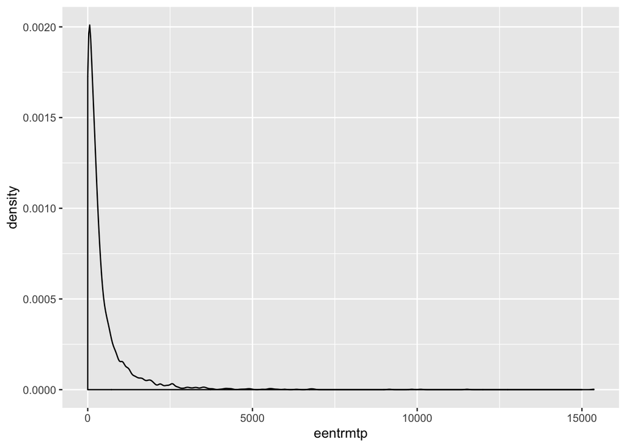

```r
gg<-ggplot(ces_train,aes(x=eentrmtp))
gg<-gg+geom_density()
gg
```

As you can see, there’s a LOT of variation in spending in this area.

# Finding and understanding variables

The CES is a huge dataset. As with many such datasets, it includes a codebook in excel format. Below is some code that can help you search through these large codebooks to find the variables you’re looking for.

```r
dct_1<-readxl::read_xlsx("ce_pumd_interview_diary_dictionary.xlsx",
                                sheet=2)
dct_2<-readxl::read_xlsx("ce_pumd_interview_diary_dictionary.xlsx",
                               sheet=3)

search_term<-"total expenditure"


## Look up variables
dct_1 %>% filter(grepl(search_term,
                       `Variable Description`))
```

```
## # A tibble: 6 x 14
##   Survey File  `Variable Name` `Variable Descr… Formula `Flag Name`
##   <chr>  <chr> <chr>           <chr>            <chr>   <chr>
## 1 INTER… FMLI  ERANKH          Complete income… <NA>    ERANKH_
## 2 INTER… FMLI  ERANKH          Complete income… <NA>    ERANKH_
## 3 INTER… FMLI  TOTEX4CQ        Adjusted total … TOTEXP… <NA>
## 4 INTER… FMLI  TOTEX4PQ        Adjusted total … TOTEXP… <NA>
## 5 INTER… FMLI  TOTEX4PQ        Adjusted total … TOTEXP… <NA>
## 6 INTER… FMLI  TOTEX4CQ        Adjusted total … TOTEXP… <NA>
## # … with 8 more variables: `Section Number` <chr>, `Section
## #   Description` <chr>, `Section Part` <chr>, `First Year` <dbl>, `First
## #   Quarter` <dbl>, `Last Quarter` <dbl>, `Last Year` <dbl>, Comment <lgl>
```

```r
#%>%
#  View()

search_var<-"CHILDAGE"
## Look up coding

dct_2 %>% filter(grepl(search_var,
                       `Variable Name`))
```

```
## # A tibble: 16 x 9
##    Survey File  `Variable Name` `Code Value` `Code Descripti… `First Year`
##    <chr>  <chr> <chr>           <chr>        <chr>                   <dbl>
##  1 DIARY  FMLD  CHILDAGE        0            No children              1998
##  2 DIARY  FMLD  CHILDAGE        1            Oldest child le…         1998
##  3 DIARY  FMLD  CHILDAGE        2            Oldest child ag…         1998
##  4 DIARY  FMLD  CHILDAGE        3            All children ag…         1998
##  5 DIARY  FMLD  CHILDAGE        4            Oldest child ag…         1998
##  6 DIARY  FMLD  CHILDAGE        5            All children ag…         1998
##  7 DIARY  FMLD  CHILDAGE        6            Oldest child ag…         1998
##  8 DIARY  FMLD  CHILDAGE        7            All children ag…         1998
##  9 INTER… FMLI  CHILDAGE        0            No children              1996
## 10 INTER… FMLI  CHILDAGE        1            Oldest child le…         1996
## 11 INTER… FMLI  CHILDAGE        2            Oldest child ag…         1996
## 12 INTER… FMLI  CHILDAGE        3            All children ag…         1996
## 13 INTER… FMLI  CHILDAGE        4            Oldest child ag…         1996
## 14 INTER… FMLI  CHILDAGE        5            All children ag…         1996
## 15 INTER… FMLI  CHILDAGE        6            Oldest child ag…         1996
## 16 INTER… FMLI  CHILDAGE        7            All children ag…         1996
## # … with 3 more variables: `First Quarter` <dbl>, `Last Year` <dbl>, `Last
## #   Quarter` <dbl>
```

```r
#%>%
#  View()
```

# Basic Model

Let’s start with a basic model, looking at spending on entertainment expenses as a function of all spending.

```r
lm1<-lm(eentrmtp~totexppq,data=ces_train);summary(lm1)
```

```
##
## Call:
## lm(formula = eentrmtp ~ totexppq, data = ces_train)
##
## Residuals:
##     Min      1Q  Median      3Q     Max
## -5511.6  -236.1  -119.9    69.2 13853.2
##
## Coefficients:
##              Estimate Std. Error t value Pr(>|t|)
## (Intercept) 1.046e+02  1.736e+01   6.023 1.92e-09 ***
## totexppq    3.637e-02  1.115e-03  32.619  < 2e-16 ***
## ---
## Signif. codes:  0 '***' 0.001 '**' 0.01 '*' 0.05 '.' 0.1 ' ' 1
##
## Residual standard error: 723.1 on 2956 degrees of freedom
## Multiple R-squared:  0.2647, Adjusted R-squared:  0.2644
## F-statistic:  1064 on 1 and 2956 DF,  p-value: < 2.2e-16
```

# Log transform

The problem with this model is that the dependent variable is on an exponential scale. Almost any variable related to money will also be on an exponential scale, as will any variable where the underlying units are on different scales (e.g. number of teachers in a school district, which can vary from 10 to 10 thousand). To deal with this issue, we can use the log transformation, which transforms the variable into the power of $e$ that equals the variable:

$$ln(x)=log_e(x)=y,e^y=x$$

We nearly always just call this the “log” transformation, but it’s actually the natural log, or log base $e$.

When we just transform the dependent variable, it’s called a log transform in the context of regression:

```r
lm2<-lm(log(eentrmtp+1)~totexppq,data=ces_train);summary(lm2)
```

```
##
## Call:
## lm(formula = log(eentrmtp + 1) ~ totexppq, data = ces_train)
##
## Residuals:
##      Min       1Q   Median       3Q      Max
## -11.3730  -0.4025   0.6479   1.3864   3.7759
##
## Coefficients:
##              Estimate Std. Error t value Pr(>|t|)
## (Intercept) 4.057e+00  5.071e-02   80.00   <2e-16 ***
## totexppq    7.257e-05  3.257e-06   22.28   <2e-16 ***
## ---
## Signif. codes:  0 '***' 0.001 '**' 0.01 '*' 0.05 '.' 0.1 ' ' 1
##
## Residual standard error: 2.112 on 2956 degrees of freedom
## Multiple R-squared:  0.1438, Adjusted R-squared:  0.1435
## F-statistic: 496.4 on 1 and 2956 DF,  p-value: < 2.2e-16
```

Note that 1 was added to the dependent variable, this is because you can’t take the log of 0.

# Log-log transform

When we transform both the dependent and independent variables, it’s called a log-log transform:

```r
lm3<-lm(log(eentrmtp+1)~log(totexppq+1),data=ces_train);summary(lm3)
```

```
##
## Call:
## lm(formula = log(eentrmtp + 1) ~ log(totexppq + 1), data = ces_train)
##
## Residuals:
##     Min      1Q  Median      3Q     Max
## -7.5372 -0.5674  0.5717  1.2879  3.7229
##
## Coefficients:
##                   Estimate Std. Error t value Pr(>|t|)
## (Intercept)        -6.8082     0.3475  -19.59   <2e-16 ***
## log(totexppq + 1)   1.3181     0.0393   33.54   <2e-16 ***
## ---
## Signif. codes:  0 '***' 0.001 '**' 0.01 '*' 0.05 '.' 0.1 ' ' 1
##
## Residual standard error: 1.943 on 2956 degrees of freedom
## Multiple R-squared:  0.2756, Adjusted R-squared:  0.2754
## F-statistic:  1125 on 1 and 2956 DF,  p-value: < 2.2e-16
```

# Duan’s smearing estimator

It would seem to be natural to take the results of a log-transformed regression and simply back transform them, so that the the prediction would just be the exponent $e^y$. This doesn’t work, though– it needs to be adjusted. The adjustment is pretty simply, and it’s called Duan’s smearing estimator. It involves taking the average of the exponentiated residuals, then multiplying the exponentatied prediction by that average. The steps are below, where `ds` is the smearing estimator.

```r
ces_train<-ces_train%>%
  add_residuals(lm3)%>% # Adds residuals
  add_predictions(lm3) #adds predictions

## Add smearing estimator and adjusted predictions
ces_train%>%
  mutate(ds=mean(exp(resid),na.rm=TRUE))%>% #ds= mean of exponentiated resids
  mutate(pred_raw=exp(pred))%>% # unadjusted exponentiated prediction
  mutate(adj_pred=exp(pred)*ds)-> # adjusted exp prediction: correct one
  ces_train

#ces_train%>%select(pred,pred_raw,ds,adj_pred)%>%View()
```

If you’re reporting RMSE based on a model with an exponentiated dependent variable, you need to use the smearing estimator.

# Reporting RMSE from Duan’s smearing estimator

```r
## Calculate rmse
rmse_mod3<-ModelMetrics::rmse(ces_train$eentrmtp,ces_train$adj_pred)
```

# Training, testing and submitting predictions

Kaggle is a very popular site for competing in data science. Organizations submit their data and ask for predictions. The users who submit the best predictions can win prizes, and sometimes are then hired by the companies who submitted their data. This week, we’ll run our very own Kaggle competition, predicting entertainment spending from the CES.

```r
lm3<-lm(log(eentrmtp+1)~log(totexppq+1),data=ces_train);summary(lm3)
```

```
##
## Call:
## lm(formula = log(eentrmtp + 1) ~ log(totexppq + 1), data = ces_train)
##
## Residuals:
##     Min      1Q  Median      3Q     Max
## -7.5372 -0.5674  0.5717  1.2879  3.7229
##
## Coefficients:
##                   Estimate Std. Error t value Pr(>|t|)
## (Intercept)        -6.8082     0.3475  -19.59   <2e-16 ***
## log(totexppq + 1)   1.3181     0.0393   33.54   <2e-16 ***
## ---
## Signif. codes:  0 '***' 0.001 '**' 0.01 '*' 0.05 '.' 0.1 ' ' 1
##
## Residual standard error: 1.943 on 2956 degrees of freedom
## Multiple R-squared:  0.2756, Adjusted R-squared:  0.2754
## F-statistic:  1125 on 1 and 2956 DF,  p-value: < 2.2e-16
```

Check its fit to the training data

```r
## Add smearing estimator and adjusted predictions
ces_train%>%
  add_residuals(lm3)%>%
  add_predictions(lm3)%>%
  mutate(ds=mean(exp(resid),na.rm=TRUE))%>% # create "smearing" estimator ds
  mutate(adj_pred=exp(pred)*ds)-> # adjust using smearing estimator
  ces_train
```

# Generate predictions from the testing data

```r
load("ces_test.Rdata")

ces_test%>%
  add_predictions(lm3)%>%
  mutate(ds=mean(exp(ces_train$resid),na.rm=TRUE))%>% # create "smearing" estimator ds
  mutate(predict=exp(pred)*ds)-> # adjust using smearing estimator
  ces_test
```

# Submit predictions

```r
ces_test%>%select(cuid,predict)->ces_submit

write_csv(ces_submit,path="group_x_predictions.csv")
```

# Upload predictions to github repo

I will test your group predictions against my “held out” data, like so:

```r
load("~/hod_datasci_keys/ces_hold.Rdata")
ces_submit<-read_csv("group_x_predictions.csv")
ces_hold<-left_join(ces_hold,ces_submit,by="cuid")
team_rmse<-ModelMetrics::rmse(ces_hold$eentrmtp,ces_hold$predict)
team_rmse
```

```
## [1] 1066.696
```

# Our Kaggle competition